# A Can Of Worms

Thibaud Decaëns , George G. Brown , Erin K. Cameron , Nico Eisenhauer , Sylvain Gérard , Arnaud Goulpeau , Mickaël Hedde , Marie-Eugénie Maggia , Jérôme Mathieu , Helen R. P. Phillips , Eric Marcon  
2024 juillet 20

This appendix allows reproducing the results and figures of the article “A can of worms: estimating the global number of earthworm species”. It is organised as follows:

- Section 1 contains the estimation of the different variations on Joppa’s model.
- Section 2 produces the figures.

# Estimating the number of species from the global checklist

## Models

### Joppa’s original Model

The logarithm of the number of species discovered for each unit of time is given by the model

$$\log{S_i} = \log{
\left(
T_i
\left(\beta_1 + \beta_2 Y_i \right)
\left(S_T - \sum_{j=0}^{i}{S_i} \right)
\right)
}
+ \mathcal{N}\left(0, \sigma^2 \right)$$
that is estimated below. Notations are those of the article: $S_i$ is the number of species described in a given interval ($Y_i = i$, numbered sequentially from 1). It depends on the taxonomic effort, i.e. the number of taxonomists ($T_i$) actively describing species during that period, and the unknown number of species remaining to be described, that is the total number of species ($S_T$) minus those already discovered $\sum_{j=0}^{i}{S_i}$ where $S_0$ is the number of known species before $Y_1$). Along time, taxonomists were expected to become more efficient, i.e. the discovery rate of unknown species per taxonomist was assumed to increase linearly: $\beta_1$ if the efficiency before $Y_1$ and $\beta_2$ is the progress rate.

### No progress model

We force the taxonomic efficiency to be constant. It equals $\beta_1$.

$$\log{S_i} = \log{
\left(
T_i
\beta_1
\left(S_T - \sum_{j=0}^{i}{S_i} \right)
\right)
}
+ \mathcal{N}\left(0, \sigma^2 \right)$$

## Data

The table `checklist` contains columns `Y`, `T` and `S`. They contain the period of time $Y_i = i$, the number of active taxonomists $T_i$ and the number of published species $S_i$. The first period ($i = 1$) is 1822-1827. The last one ($i = 41$) is 2018-2022.

```r
library("tidyverse")
read_csv2("data/checklist.csv") %>%
    # Delete periods without new species
filter(S > 0) %>%
    print() -> checklist
```

```
# A tibble: 40 × 3
       Y     T     S
   <dbl> <dbl> <dbl>
 1     1     1     1
 2     2     1    15
 3     3     1     5
 4     4     3     4
 5     6     2     4
 6     7     1     1
 7     8     3     4
 8     9     1     6
 9    10     2    13
10    11     3    14
# ℹ 30 more rows
```

The initial number of known species $S_0$ is 1: *Lumbricus terrestris* Linné (1758).

```r
S_0 <- 1
```

## Estimation functions

Parameters to be estimated are $\beta_1$, $\beta_2$, …, $S_T$ and $\sigma$, gathered into a vector named $\theta$ to simplify the code. We reserved the first four elements of `theta` to store parameters $\beta_1$ to $\beta_4$ (the last two are unused in Joppa’s original model). `theta[5]` contains $S_T$ and `theta[6]` contains $\sigma$.

We first need a function to calculate $S_i$.

```r
#' Compute the number of species discovered at time `i`.
#'
#' @param i The time.
#' @param Y The vector of time periods.
#' @param model The model to estimate: 'Joppa', 'NoProgress'
#' @param theta The vector of parameters of the model
#' @param sum_S The cumulated number of species already discovered.
#' Only `sum_S[i]` is used.
#'
#' @return The number of species.
S_i <- function(i, T, Y, model = c("Joppa", "NoProgress"),
    theta, sum_S) {
    model <- match.arg(model)
    # Apply the formula corresponding to the
    # model
    if (model == "Joppa") {
        T[i] * (theta[1] + theta[2] * Y[i]) * (theta[5] -
            sum_S[i])
    } else if (model == "NoProgress") {
        T[i] * theta[1] * (theta[5] - sum_S[i])
    }
}
```

### Likelihood

The log-likelihood of the data given the parameters is given by the function `ll_data()`

```r
ll_data <- function(
    S,
    T,
    Y,
    S_0,
    model = c("Joppa", "NoProgress"),
    theta) {

  model <- match.arg(model)
  timespan <- length(Y)
  # Prepare vectors to store the number of new species...
  prediction <- numeric(timespan)
  # ... and their cumulated number
  sum_S <- numeric(timespan + 1)
  # Initial number of species
  sum_S[1] <- S_0
  # Values predicted by the model
  for (i in 1:timespan) {
    prediction[i] <- S_i(i, T, Y, model, theta, sum_S)
    # Cumulative sum
    sum_S[i + 1] <- sum_S[i] + prediction[i]
  }
  # Log-likelihood of each value of y
  loglikelihoods <- suppressWarnings(
    dnorm(
      # Actual numbers of new species
      log(S),
      # Predicted numbers of new species
      mean = log(prediction),
      # Model error
      sd = theta[6],
      log = TRUE
    )
  )
  # Log-likelihood of the data, that may contain NA's if likelihood is 0.
  ll <- sum(loglikelihoods)
  # Then, loglikelihood is -Inf
  if (is.na(ll))
    ll <- -Inf
  return(ll)
}
```

The log-likelihood of the priors depends on the model. For Joppa’s original model, it is:

```r
ll_prior <- function(theta) {
  # Log-likelihood of each parameter in its a priori distribution
  sum(
    dunif(theta[1], min = 0, max = 1, log = TRUE),        # beta_1
    dunif(theta[2], min = 0, max = 1, log = TRUE),        # beta_2
    dunif(theta[5], min = 6000, max = 1e5, log = TRUE),   # S_T
    dunif(theta[6], min = 0, max = 10, log = TRUE)        # sigma
  )
}
```

### Exploring the parameter space

The proposal function is:

```r
proposal <- function(theta, sigma_proposal) {
    # Random walk around the previous values
    rnorm(length(theta), mean = theta, sd = sigma_proposal)
}
```

The Markov chain is:

```r
MetropolisMCMC <- function(S, T, Y, S_0, model = c("Joppa",
    "NoProgress"), sigma_proposal, theta_0, iterations) {
    model <- match.arg(model)
    # Storage. Each row of the table contains an
    # iteration, the columns contain theta
    chain <- matrix(nrow = iterations + 1, ncol = length(theta_0))
    # Parameter names
    colnames(chain) <- names(theta_0)
    # Save the loglikelihoods (1: ll_data, 2:
    # ll_prior)
    ll_model <- matrix(nrow = iterations + 1, ncol = 2)
    colnames(ll_model) <- c("data", "prior")
    # Initial values
    chain[1, ] <- theta_0
    ll_model[1, 1] <- ll_data(S = S, T = T, Y = Y,
        S_0 = S_0, model = model, theta = theta_0)
    ll_model[1, 2] <- ll_prior(theta = theta_0)
    # Initialise a progress bar
    # cli::cli_progress_bar('Running the MCMC',
    # total = iterations)
    pgb <- txtProgressBar(min = 0, max = iterations)
    # Markov chain
    for (i in 1:iterations) {
        # Proposal of a theta value
        theta_proposal <- proposal(theta = chain[i,
            ], sigma_proposal = sigma_proposal)
        # Likelihoods
        ll_model[i + 1, 1] <- ll_data(S = S, T = T,
            Y = Y, S_0 = S_0, model = model, theta = theta_proposal)
        ll_model[i + 1, 2] <- ll_prior(theta = theta_proposal)
        # Acceptance
        if (sum(ll_model[i, ]) == -Inf) {
            # Systematic acceptance if the
            # previous likelihood was zero
            l_ratio <- Inf
        } else {
            # Likelihood ratio between the
            # proposition and the previous value
            # of theta
            l_ratio <- exp(sum(ll_model[i + 1, ]) -
                sum(ll_model[i, ]))
        }
        # Accept or not
        if (runif(1) < l_ratio) {
            chain[i + 1, ] <- theta_proposal
        } else {
            chain[i + 1, ] <- chain[i, ]
            # Save likelihood values
            ll_model[i + 1, ] <- ll_model[i, ]
        }
        # cli::cli_progress_update()
        setTxtProgressBar(pgb, i)
    }
    # Return a complete table: theta and
    # likelihood
    return(cbind(chain, LogLikelihood = ll_model))
}
```

## Estimation of the models

### Joppa’s original Model

The model is estimated after setting up the parameters.

```r
# Number of steps
iterations <- 1e7

# Standard deviation of the random walk (for each parameter). Tuned by trials.
sigma_proposal <- c(1e-4, 1e-7, 0, 0, 1e3, 1e-1)
# Initial value of the parameters
theta_0 <- c(
  1e-2,  # beta_1
  1e-6,  # beta_2
  0, 0,  # Unused
  1e4,   # S_T
  1      # sigma
)
names(theta_0) <- c("beta_1", "beta_2", NA, NA, "S_T", "sd")

# Launch the Markov chain
chain <- MetropolisMCMC(
  S = checklist$S,
  T = checklist$T,
  Y = checklist$Y,
  S_0 = S_0,
  model = "Joppa",
  sigma_proposal = sigma_proposal,
  theta_0 = theta_0,
  iterations =  iterations
)
```

#### Raw results

This first view of the results allows checking for the convergence of the chain and choosing the ratio of the thinning of the data to eliminate autocorrelation.

The evolution of the likelihood along the chain is first checked.

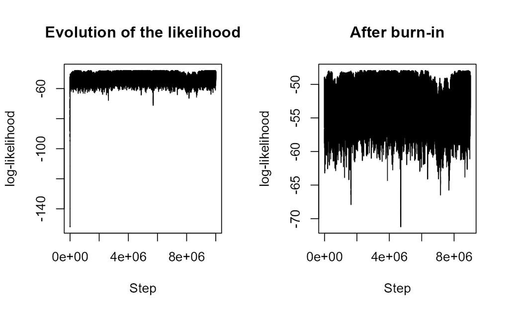

```r
par(mfrow = c(1, 2))
plot(chain[, length(theta_0) + 1], type = "l", main = "Evolution of the likelihood",
    xlab = "Step", ylab = "log-likelihood")
burn_in <- iterations/10
plot(chain[-(1:burn_in), length(theta_0) + 1], type = "l",
    main = "After burn-in", xlab = "Step", ylab = "log-likelihood")
```

The likelihood is quite stable after the burn-in.

Along the chain, after burn-in, the estimated parameters are:

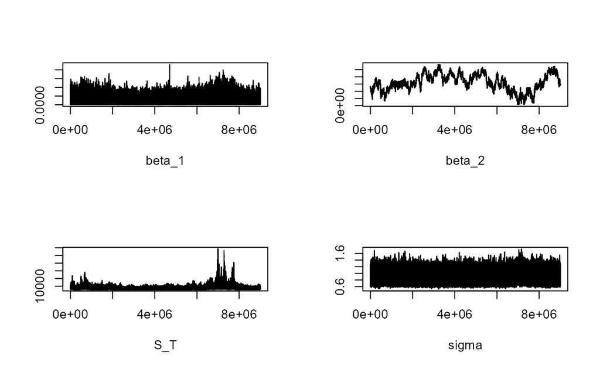

```r
par(mfrow = c(2, 2))
plot(chain[-(1:burn_in), 1], type = "l", main = "",
    xlab = "beta_1", ylab = "")
plot(chain[-(1:burn_in), 2], type = "l", main = "",
    xlab = "beta_2", ylab = "")
plot(chain[-(1:burn_in), 5], type = "l", main = "",
    xlab = "S_T", ylab = "")
plot(chain[-(1:burn_in), 6], type = "l", main = "",
    xlab = "sigma", ylab = "")
```

The acceptance rate in the Markov chain is:

```r
(acceptance <- 1 - mean(duplicated(chain[-(1:burn_in),
    ])))
```

```
[1] 0.3510886
```

The autocorrelation of the estimations is shown:

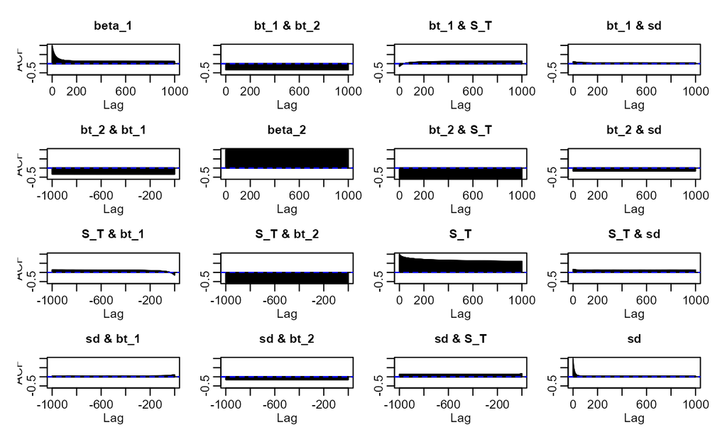

```r
acf(chain[-(1:burn_in), c(1:2, 5:6)], lag.max = 1000)
```

Our choice is to keep an estimation out of 5000.

```r
# Delete burn-in and keep 1/5000 of the data
posterior <- chain[-(1:burn_in), ][seq(1, iterations -
    burn_in, by = 5000), ]
```

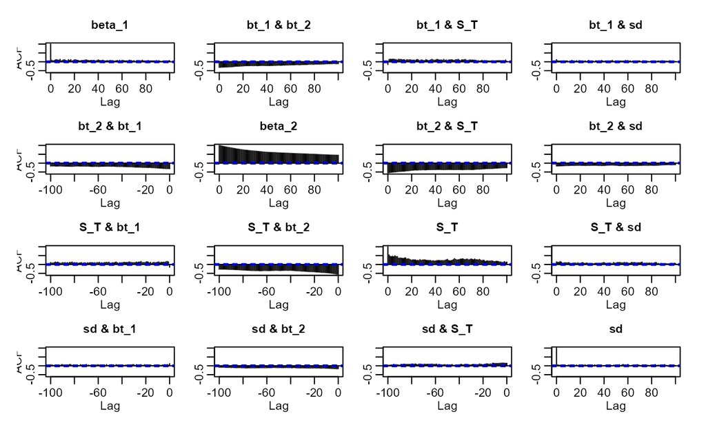

```r
acf(posterior[, c(1:2, 5:6)], lag.max = 100)
```

#### Distribution of the parameters

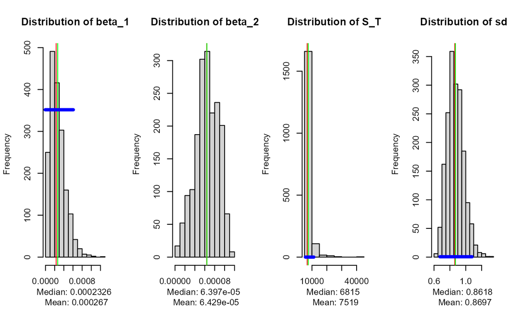

```r
library("HDInterval")
par(mfrow = c(1, 4))
for (i in c(1:2, 5:6)) {
    title <- paste("Distribution of", names(theta_0)[i])
    median <- format(median(posterior[, i]), digits = 4)
    mean <- format(mean(posterior[, i]), digits = 4)
    hist(posterior[, i], xlab = paste("Median:", median,
        "\n", "Mean:", mean), main = title)
    abline(v = median, col = "red")
    abline(v = mean, col = "green")
    the_hdi <- hdi(density(posterior[, i]), allowSplit = TRUE,
        credMass = 0.95)
    ht <- attr(the_hdi, "height")
    segments(the_hdi[, 1], ht, the_hdi[, 2], ht, lwd = 4,
        col = "blue")
}
```

#### Posterior likelihood and correlations

```r
# Save the results
posterior_joppa <- as_tibble(posterior[, -(3:4)])
# Mean loglikelihood of the data
mean(posterior_joppa$data)
```

```
[1] -50.31116
```

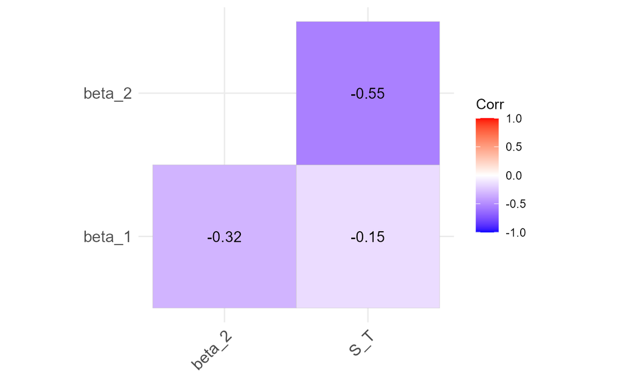

```r
library("ggcorrplot")
posterior_joppa %>%
    select(beta_1, beta_2, S_T) %>%
    cor() %>%
    ggcorrplot(type = "lower", lab = TRUE)
```

#### Taxonomic efficiency

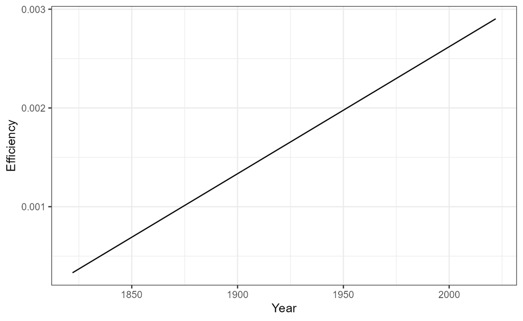

```r
tibble(Period = checklist$Y) %>%
    mutate(Year = 1817 + 5 * Period, Efficiency = (colMeans(posterior_joppa$beta_1 +
        outer(posterior_joppa$beta_2, Period), ))) %>%
    ggplot(aes(x = Year, y = Efficiency)) + geom_line()
```

### No progress model

The log-likelihood of the priors is:

```r
ll_prior <- function(theta) {
  # Log-likelihood of each parameter in its a priori distribution
  sum(
    dunif(theta[1], min = 0, max = 1, log = TRUE),       # beta_1
    dunif(theta[5], min = 6000, max = 1e5, log = TRUE),  # S_T
    dunif(theta[6], min = 0, max = 10, log = TRUE)       # sigma
  )
}
```

The model is estimated after setting up the parameters.

```r
# Standard deviation of the random walk (for each parameter). Tuned by trials.
sigma_proposal <- c(1e-4, 0, 0, 0, 1e3, 1e-1)
# Initial value of the parameters
theta_0 <- c(
  1e-2,    # beta_1
  0, 0, 0, # unused
  1e4,     # S_T
  1        # sigma
)
names(theta_0) <- c("beta_1", NA, NA, NA, "S_T", "sd")
# Launch the Markov chain
chain <- MetropolisMCMC(
  S = checklist$S,
  T = checklist$T,
  Y = checklist$Y,
  S_0 = S_0,
  model = "NoProgress",
  sigma_proposal = sigma_proposal,
  theta_0 = theta_0,
  iterations =  iterations
)
```

The acceptance rate in the Markov chain is:

```r
(acceptance <- 1 - mean(duplicated(chain[-(1:burn_in),
    ])))
```

```
[1] 0.3634703
```

We keep an estimation out of 5000.

```r
# Delete burn-in and keep 1/5000 of the data
posterior <- chain[-(1:burn_in), ][seq(1, iterations -
    burn_in, by = 5000), ]
```

#### Distribution of the parameters

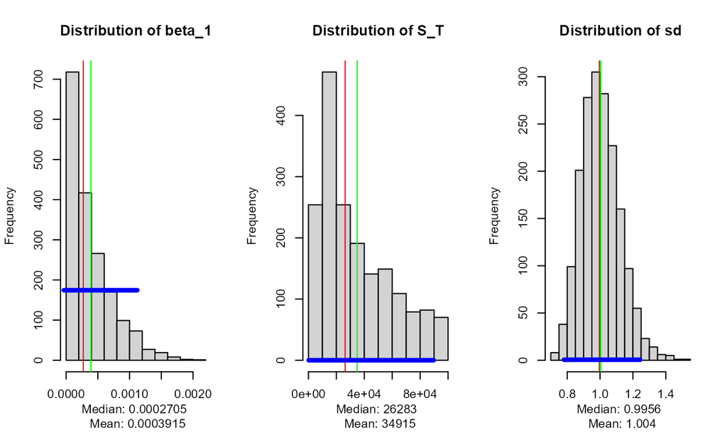

```r
par(mfrow = c(1, 3))
for (i in c(1, 5:6)) {
    title <- paste("Distribution of", names(theta_0)[i])
    median <- format(median(posterior[, i]), digits = 4)
    mean <- format(mean(posterior[, i]), digits = 4)
    hist(posterior[, i], xlab = paste("Median:", median,
        "\n", "Mean:", mean), main = title)
    abline(v = median, col = "red")
    abline(v = mean, col = "green")
    the_hdi <- hdi(density(posterior[, i]), allowSplit = TRUE,
        credMass = 0.95)
    ht <- attr(the_hdi, "height")
    segments(the_hdi[, 1], ht, the_hdi[, 2], ht, lwd = 4,
        col = "blue")
}
```

#### Posterior likelihood

```r
# Save the results
posterior_no_progress <- as.tibble(posterior[, -(2:4)])
# Mean loglikelihood of the data
mean(posterior_no_progress$data)
```

```
[1] -56.09722
```

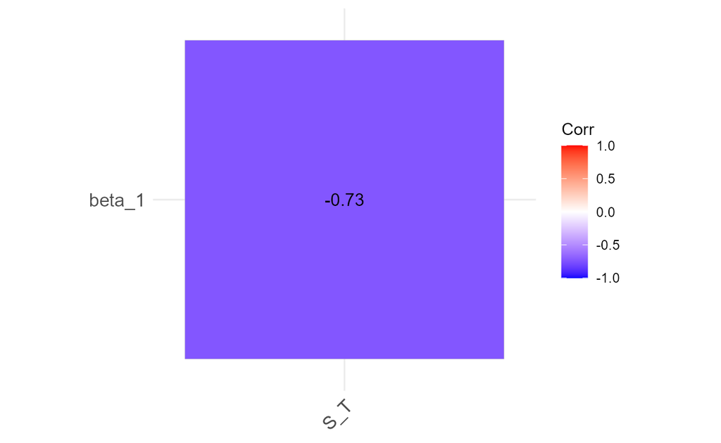

```r
library("ggcorrplot")
posterior_no_progress %>%
    select(beta_1, S_T) %>%
    cor() %>%
    ggcorrplot(type = "lower", lab = TRUE)
```

#### Taxonomic efficiency

The taxonomic efficiency is constant:

```r
median(posterior_no_progress$beta_1)
```

```
[1] 0.0002704695
```